# 1. Title:Preliminary-results

2. Team members names: Maya Hachicha, Gabriel Olawuyi, Madhav Chandarana, Radulescu Serban

15/12/2020

[figure not shown]

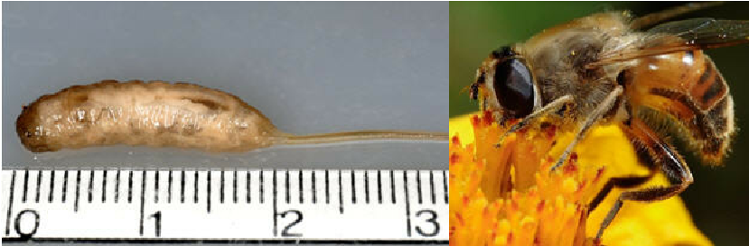

## 3. Introduction. Explain the origin and structure of your data.

Data comes from: https://peerj.com/articles/4258/, which is Effects of chronic exposure to thiamethoxam on larvae of the hoverfly Eristalis tenax (Diptera, Syrphidae).

The aquatic larvae of hoverfly were raised in lagoons with different concentrations of thiamethoxam. The paper studies the impact of the pesticide on larval development(weight gain), survival(whether the larva forms a pupa or not) , and seven adult behaviours. Five-day old larvae were exposed to six concentrations of the pesticide measured in parts per billion(ppb) – 0, 5, 15, 50, 100, and 500. 10 larval replicates per treatment 4 rounds of experiment Total of 40 larvae were studied for each treatment.

This resulted in 3 tables that we use as data frames: survival, behaviour, weight.

### a.survival

survival is a dataset with 6 column:  
1.the ID of repetition  
2.exp_round - different blocks, with 8 repetitions  
3.treatment - Control (0),T1=5, T2= 15, T3= 50, T4= 100, T5= 500 (quantity of substance applied)  
4.daysinxp - the amount of days it needs to reach pupae and so to be considered survived (5 days to time it forms a pupae)  
5.time to pup - if it never reached adulthood, daysinxp are considered 0  
6.dead - mortality (yes or no)

### b.behaviour

The behaviour data records the time spent by 7 day old adult hoverflies. Seven adult behaviours were studied for 10 minutes (600 seconds) and the time spent on each behaviour was recorded in seconds. The behaviours studied are - S- stationary GR- grooming W- walking F- flying PR- probing through the cage netting with their proboscis N- feeding on nectar, pollen, and water M- moving, which includes making small jerking motion while being stationary

1.The blocks (1,2,3,4)  
2.Sample: a notation of the enclosed space it was studied  
3.Treatment: Control (0),T1=5, T2= 15, T3= 50, T4= 100, T5= 500 (quantity of substance applied)  
4.Sex of the insect  
5.6.7.8.9.10.11. the studied behaviours  
12.The time of study is identical for all insects: 10 minutes (600 seconds)

### c.weight

1.Rep = the block and the number of the repetition  
2.Treatment (explained before)  
3.Time (1 represents day 3, 2 day 6, 3 day 9, 4 day 12); the ones that died have measured only their last living weight  
4.FIL - Found in leaves: some insects escape and are found afterwards in the surroundings  
5.weight - in grams

## 4. Objectives and hypotheses.

In this project, the objectives will be to reproduce the analysis done by the team that conducted the study. Further analysis can be conducted, at the recommendation of the coordinating professor.

### OBJECTIVE TREATMENT ON SURVIVAL

Hypothesis 1: H0: Treatments do not affect survival H1: Treatments affect survival

Hypothesis 1’: Redefine survival and redo the analyses H0’: Treatments do not affect survival H1’: Treatments affect survival

### OBJECTIVE OF BEHAVIOUR STUDY

To study if the exposure to different concentrations of thiamethoxam during the larval stage affects the behaviour of hoverflies as adults.

Hypothesis 0: The amount of thiamethoxam hoverfly larvae are exposed to affects their behaviour as adults. Hypothesis 1: The amount of thiamethoxam hoverfly larvae are exposed to does not affect their behaviour as adults.

### OBJECTIVE OF WEIGHT DATA

To analyse the response of larvae weights to different concentration of thiamethoxan Hypothesis: H0: Larval weight does not depend upon the concentration of insecticide it is exposed to. H1: Larval weight depends upon the concentration of insecticide it is exposed to.

## 5. Methods. What have you done? And what did you use to do it? Step by step, so anyone could do it again by reading this part.

Important note: you will find the code for the analysis like this:  
survival - Task1Serban.R  
weight - Task1Gabriel.R  
behaviour - Task1Madhav.R and Task1Maya.R

### Methods for survival:

We plot the survival to study the effects of blocks and treatments. As we observe differences, we proceed to do a linear model with the blocks as median. It confirms that Treatment 500 has an effect on survival. After that, we do a linear model to study the interaction between treatments and blocks. With a p_value = 0.3738 we conclude that no interaction can be proved. We proceed to find if there are any different effects of treatment on survival. Because the data is categorical, we use a fisher test. After a simple fisher test shows significant differences between treatments, we proceed with a multicomparison fisher test. It showed that treatment500 has significant differences with all of them, between the others there is no significant difference.

The plot will also be ploted with Kaplan-Meier curves for a better visualisation.

We also did an anova for the effect of treatment on the time to pupate. The effects of the blocks and the interaction between blocks and treatment was studied. No interaction (p = 0.27), we proceed with the anova. The anova has shown significantly different effects. Furthermore, a HSD test showed two types of effects: a and b.

### Methods for weight

Initial and final weight were made into different data frames. This was needed to find weight gain of the larvae. There is a difference in the number of rows between the newly created data frames, because some larvae escaped before the final weight and some immediately after the first weight, as a such, replicates having both the final and the initial weight were pulled to make a data frame. ANOVA and a Kruskal-Wallis test were used to check the effect of treatment on the larval weight. Shapiro.test was used to check normality of data.

### Metods for behaviour:

we sourced our data from the PeerJ article mentioned above. We did Principal Component Analysis to study the impact of thiamethoxam on adult behaviour.Other metods were too complex to be explained here, detailed with plots in results.

## 6. Results. Figures and tables with captions and description of what do they mean.

### a1. Effect of treatments on survival (multi-comp Fisher Test):

#### treatment500 has significant differences with all of them, between the others there is no significant difference

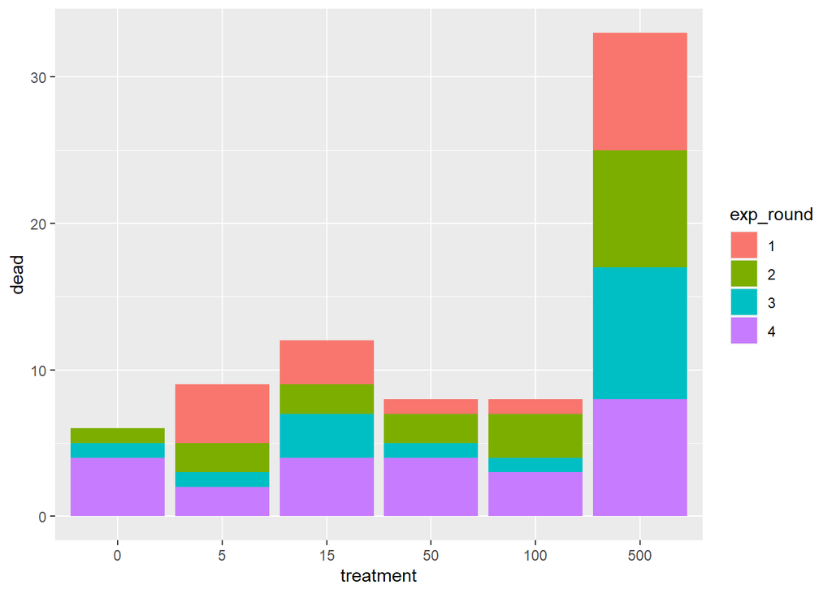

```r
#Step 1: We plot it in order to see if:
#-there are differences between the blocks
#-there are differences between the treatments

survival <- surv

survival$treatment <- as.factor(survival$treatment)
survival$exp_round <- as.factor(survival$exp_round)
ggplot(survival, aes(x=treatment, y=dead, fill=exp_round)) +
  geom_bar(stat="identity")
```

```r
#It is obvious that the treatment500 is different from the others.
#It is hard to observe if there are differences between blocks, we proced to do a linear model with the blocks as median

lm1 <- lm(dead ~ treatment + exp_round, data= survival)
#summary(lm1)

#P value is smaller than 0.05 for: treatment500. The other treatments and the blocks show a p_value smaller than 0.5 so no significant effect.
#We proceed to study the interaction betwenn treatments and blocks.

lm1 <- lm(dead ~ treatment + exp_round +
            I(as.numeric(treatment) * as.numeric(exp_round)),
          data= survival)
#summary(lm1)

#No interaction between treatments and blocks. (p_value = 0.3738)
#We proceed with the fisher test, as the data is categorical.

t1 <- table(survival$treatment, survival$dead)
#fisher.test(t1, simulate.p.value=TRUE)

#A simple fisher test tells us that there are significant differences between treatments.
#We proceed with a multi-comparation fisher test.

fisher.multcomp(t1)
```

```
##
##         Pairwise comparisons using Fisher's exact test for count data
##
## data:  t1
##
##             0         5        15        50       100
## 5   7.035e-01         -         -         -         -
## 15  2.469e-01 7.035e-01         -         -         -
## 50  7.035e-01 1.000e+00 5.430e-01         -         -
## 100 7.035e-01 1.000e+00 5.430e-01 1.000e+00         -
## 500 1.691e-08 3.294e-07 4.814e-05 1.321e-07 1.321e-07
##
## P value adjustment method: fdr
```

```r
#Treatment 500 has significant differences with all of them, between the others there is no significant difference
```